# Intro to R Markdown (Part 1)

Soane Mota

May 4, 2019

The `rmarkdown` package is a relatively complete ecosystem for authoring documents. The tasks that you could do with R Markdown are:

- Compile a single R Markdown document to a report in different formats, such as PDF, HTML, or Word.
- Create notebooks in which you can directly run code chunks interactively.
- Make slides for presentations (HTML5, LaTeX Beamer, or PowerPoint).
- Produce dashboards with flexible, interactive, and attractive layouts.
- Build interactive applications based on Shiny.
- Write journal articles.
- Author books of multiple chapters.
- Generate websites and blogs.

## Document Metadata

The body of a document follows the metadata. * The syntax for text (also known as prose or narratives) is Markdown. * Two types of computer code - R code chunks and inline R code

### Markdown Syntax

You can write your report in plain text.

- *Italic* is surrounded by underscores or asterisks, e.g., `_text_` or `*text*`.
- **Bold** the text by using a pair of double asterisks (`**text**`)
- To subscript the text uses a pair of tildes (~) (e.g., `H~2~O` renders H<sub>2</sub>O).
- To superscript uses a pair of carets (^) (e.g., `Cu^2+^` renders Cu<sup>2+</sup>).
- Hyperlinks `[text](link)`, e.g., `[RStudio](https://www.rstudio.com)`
- Images: just add an exclamation mark, e.g., `![alt text or image title](path/to/image)`.
- Footnotes: put inside the square brackets after a caret `^[]`, e.g., `^[This is a footnote.]`.

Section headers:

`# First-level header`

`## Second-level header`

`### Third-level header`

Unordered list:

The items start with *, -, or +, and it can be nested one list within another list by indenting the sub-list

```
- one item
- one item
- one item
    - one more item
    - one more item
    - one more item
```

Ordered list:

The items start with numbers (you can also nest lists within lists)

```
1. the first item
2. the second item
3. the third item
    - one unordered item
    - one unordered item
```

### R code chunks and inline R code

To insert an R code chunk you can either use the RStudio toolbar (the Insert button) or the keyboard shortcut `Ctrl + Alt + I` (`Cmd + Option + I` on macOS).

In a code chunk you can produce text output, tables, or graphics and you have control over all these output via chunk options, which can be provided inside the curly braces (between `` ```{r and } ``).

## Plots

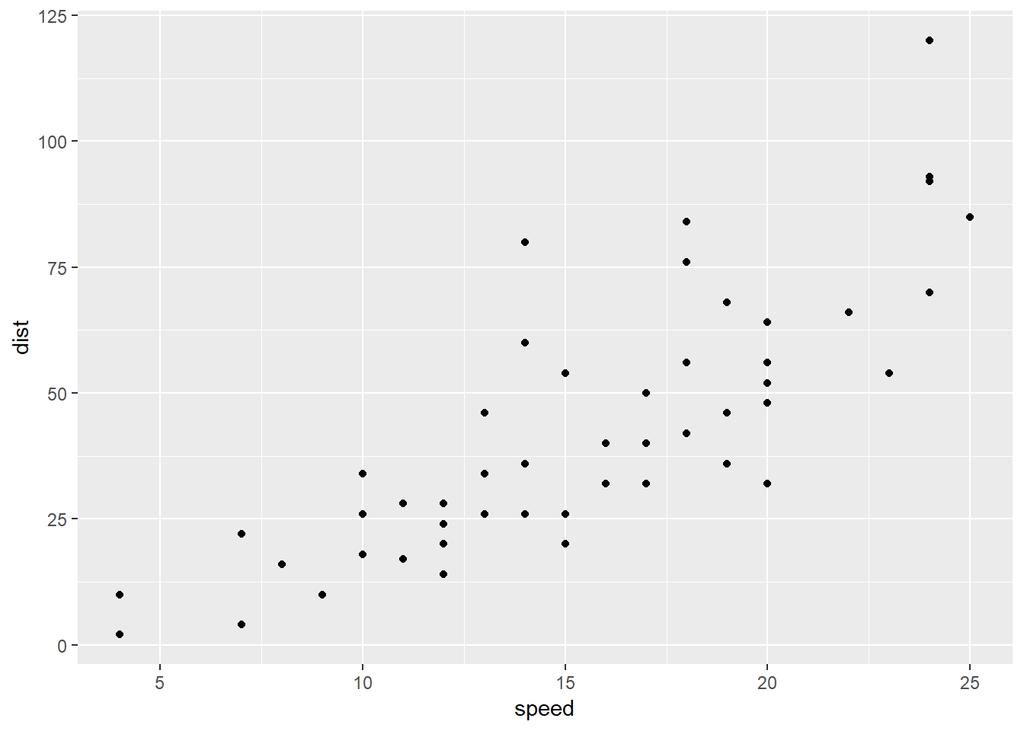

```r
# All defaults
ggplot(cars, aes(speed, dist)) + geom_point()
```

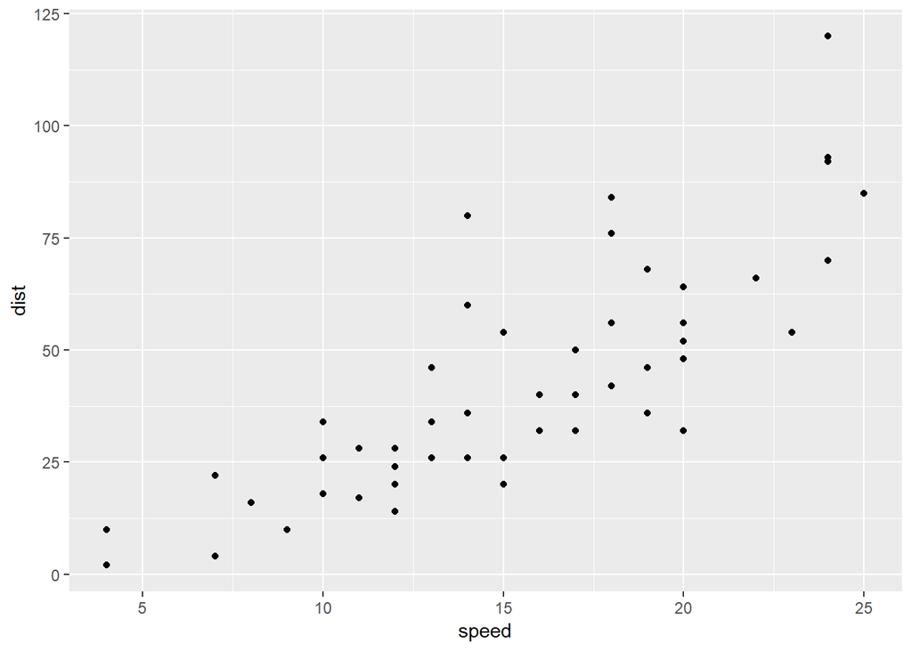

```r
ggplot(cars, aes(speed, dist)) + geom_point()
```

## Tables

To work with tables, we can use the libraries

```
install.packages("kableExtra")
```

```r
library(knitr)
library(kableExtra)
```

Let’s use the mtcars dataset available in R

```r
dt <- mtcars[1:7, 1:6]
```

The basic HTML output of `kable`.

```r
kable(dt)
```

|  | mpg | cyl | disp | hp | drat | wt |
| --- | --- | --- | --- | --- | --- | --- |
| Mazda RX4 | 21.0 | 6 | 160 | 110 | 3.90 | 2.620 |
| Mazda RX4 Wag | 21.0 | 6 | 160 | 110 | 3.90 | 2.875 |
| Datsun 710 | 22.8 | 4 | 108 | 93 | 3.85 | 2.320 |
| Hornet 4 Drive | 21.4 | 6 | 258 | 110 | 3.08 | 3.215 |
| Hornet Sportabout | 18.7 | 8 | 360 | 175 | 3.15 | 3.440 |
| Valiant | 18.1 | 6 | 225 | 105 | 2.76 | 3.460 |
| Duster 360 | 14.3 | 8 | 360 | 245 | 3.21 | 3.570 |

The HTML table using the `kable_styling()` apply twitter bootstrap theme to the table.

```r
dt %>%
  kable() %>%
  kable_styling()
```

|  | mpg | cyl | disp | hp | drat | wt |
| --- | --- | --- | --- | --- | --- | --- |
| Mazda RX4 | 21.0 | 6 | 160 | 110 | 3.90 | 2.620 |
| Mazda RX4 Wag | 21.0 | 6 | 160 | 110 | 3.90 | 2.875 |
| Datsun 710 | 22.8 | 4 | 108 | 93 | 3.85 | 2.320 |
| Hornet 4 Drive | 21.4 | 6 | 258 | 110 | 3.08 | 3.215 |
| Hornet Sportabout | 18.7 | 8 | 360 | 175 | 3.15 | 3.440 |
| Valiant | 18.1 | 6 | 225 | 105 | 2.76 | 3.460 |
| Duster 360 | 14.3 | 8 | 360 | 245 | 3.21 | 3.570 |

There are some predefined classes that you can use as `striped`, `bordered`, `hover`, `condensed`, and `responsive`.

```r
kable(dt) %>%
  kable_styling(bootstrap_options = c("striped", "hover"))
```

|  | mpg | cyl | disp | hp | drat | wt |
| --- | --- | --- | --- | --- | --- | --- |
| Mazda RX4 | 21.0 | 6 | 160 | 110 | 3.90 | 2.620 |
| Mazda RX4 Wag | 21.0 | 6 | 160 | 110 | 3.90 | 2.875 |
| Datsun 710 | 22.8 | 4 | 108 | 93 | 3.85 | 2.320 |
| Hornet 4 Drive | 21.4 | 6 | 258 | 110 | 3.08 | 3.215 |
| Hornet Sportabout | 18.7 | 8 | 360 | 175 | 3.15 | 3.440 |
| Valiant | 18.1 | 6 | 225 | 105 | 2.76 | 3.460 |
| Duster 360 | 14.3 | 8 | 360 | 245 | 3.21 | 3.570 |

For shorter row height, you can use the option `condensed`.

```r
kable(dt) %>%
  kable_styling(bootstrap_options = c("striped", "hover", "condensed"))
```

|  | mpg | cyl | disp | hp | drat | wt |
| --- | --- | --- | --- | --- | --- | --- |
| Mazda RX4 | 21.0 | 6 | 160 | 110 | 3.90 | 2.620 |
| Mazda RX4 Wag | 21.0 | 6 | 160 | 110 | 3.90 | 2.875 |
| Datsun 710 | 22.8 | 4 | 108 | 93 | 3.85 | 2.320 |
| Hornet 4 Drive | 21.4 | 6 | 258 | 110 | 3.08 | 3.215 |
| Hornet Sportabout | 18.7 | 8 | 360 | 175 | 3.15 | 3.440 |
| Valiant | 18.1 | 6 | 225 | 105 | 2.76 | 3.460 |
| Duster 360 | 14.3 | 8 | 360 | 245 | 3.21 | 3.570 |

For more examples of how to manipulate table styles [here](https://cran.r-project.org/web/packages/kableExtra/vignettes/awesome_table_in_html.html)

Now, it is your turn to create a beatiful HTML document in Rmarkown. Use one of the datasets from the last meeting and please, includes:

- Image
- GIF
- text
- plots
- tables
- hyperlinks
- Titles
- Other things you want

[figure not shown]

This presentation was based on

- [R Markdown: The Definitive Guide](https://bookdown.org/yihui/rmarkdown/)
- [R Markdown Cheat Sheet](https://www.rstudio.com/wp-content/uploads/2015/02/rmarkdown-cheatsheet.pdf)
- [HTML Table with knitr::kable and kableExtra](https://cran.r-project.org/web/packages/kableExtra/vignettes/awesome_table_in_html.html)